# stat 432 hw7

Author

Lu Gong

# HW7

### question 1

```r
library(MASS)

heart <- read.csv("data/saheart.csv")
heart$famhist <- factor(heart$famhist, levels = c("Absent", "Present"))
X <- data.matrix(heart[, names(heart) != "chd"])
y <- heart$chd
n <- nrow(X)

priors <- as.numeric(table(y) / n)
means <- cbind(colMeans(X[y == 0, ]), colMeans(X[y == 1, ]))
colnames(means) <- c("0", "1")
center0 <- sweep(X[y == 0, ], 2, means[, 1])
center1 <- sweep(X[y == 1, ], 2, means[, 2])
pooled <- (t(center0) %*% center0 + t(center1) %*% center1) / (n - 2)

knitr::kable(data.frame(class = 0:1, prior = priors), digits = 4)
```

| class | prior |
| --- | --- |
| 0 | 0.6537 |
| 1 | 0.3463 |

```r
knitr::kable(means, digits = 3)
```

|  | 0 | 1 |
| --- | --- | --- |
| sbp | 135.460 | 143.738 |
| tobacco | 2.635 | 5.525 |
| ldl | 4.344 | 5.488 |
| adiposity | 23.969 | 28.120 |
| famhist | 1.318 | 1.600 |
| typea | 52.368 | 54.494 |
| obesity | 25.737 | 26.623 |
| alcohol | 15.931 | 19.145 |
| age | 38.854 | 50.294 |

```r
knitr::kable(pooled, digits = 2)
```

|  | sbp | tobacco | ldl | adiposity | famhist | typea | obesity | alcohol | age |
| --- | --- | --- | --- | --- | --- | --- | --- | --- | --- |
| sbp | 405.43 | 14.59 | 4.58 | 49.16 | 0.34 | -15.59 | 18.94 | 64.40 | 95.13 |
| tobacco | 14.59 | 19.24 | 0.76 | 7.54 | 0.02 | -2.06 | 1.83 | 20.52 | 22.77 |
| ldl | 4.58 | 0.76 | 4.00 | 6.03 | 0.09 | 0.34 | 2.66 | -2.53 | 6.48 |
| adiposity | 49.16 | 7.54 | 6.03 | 56.75 | 0.43 | -5.31 | 22.71 | 16.12 | 60.51 |
| famhist | 0.34 | 0.02 | 0.09 | 0.43 | 0.23 | 0.08 | 0.18 | 0.77 | 1.00 |
| typea | -15.59 | -2.06 | 0.34 | -5.31 | 0.08 | 95.57 | 2.64 | 7.96 | -20.28 |
| obesity | 18.94 | 1.83 | 2.66 | 22.71 | 0.18 | 2.64 | 17.62 | 4.69 | 15.70 |
| alcohol | 64.40 | 20.52 | -2.53 | 16.12 | 0.77 | 7.96 | 4.69 | 598.28 | 27.89 |
| age | 95.13 | 22.77 | 6.48 | 60.51 | 1.00 | -20.28 | 15.70 | 27.89 | 184.13 |

```r
inverse <- solve(pooled)
scores <- matrix(NA, n, 2)
for (k in 1:2) {
  mu <- means[, k]
  scores[, k] <- X %*% inverse %*% mu -
    as.numeric(t(mu) %*% inverse %*% mu) / 2 + log(priors[k])
}
manual_pred <- max.col(scores, ties.method = "first") - 1
dim(X)
```

```
[1] 462   9
```

```r
dim(means)
```

```
[1] 9 2
```

```r
dim(pooled)
```

```
[1] 9 9
```

```r
dim(scores)
```

```
[1] 462   2
```

```r
table(observed = y, predicted = manual_pred)
```

```
        predicted
observed   0   1
       0 258  44
       1  73  87
```

```r
lda_fit <- lda(X, grouping = y, prior = priors)
lda_pred <- predict(lda_fit, X)$class
table(observed = y, predicted = lda_pred)
```

```
        predicted
observed   0   1
       0 258  44
       1  73  87
```

```r
all(manual_pred == as.numeric(as.character(lda_pred)))
```

```
[1] TRUE
```

The results match.

### question 2

```r
digit_train <- read.csv("data/zip-train.csv.gz", header = FALSE)
digit_test <- read.csv("data/zip-test.csv.gz", header = FALSE)
x_train <- as.matrix(digit_train[, -1])
x_test <- as.matrix(digit_test[, -1])
y_train <- factor(digit_train[, 1], levels = 0:9)
y_test <- factor(digit_test[, 1], levels = 0:9)

pixel_order <- order(apply(x_train, 2, var), decreasing = TRUE)
pixels40 <- pixel_order[1:40]
qda40 <- qda(x_train[, pixels40], grouping = y_train)
pred40 <- predict(qda40, x_test[, pixels40])$class
table(observed = y_test, predicted = pred40)
```

```
        predicted
observed   0   1   2   3   4   5   6   7   8   9
       0 319   0  24   6   2   2   1   0   5   0
       1   0 238   5   0  11   0   7   0   3   0
       2   8   0 168   8   8   3   0   0   3   0
       3   5   0   4 128   0  14   0   0  15   0
       4   0   2  13   1 150   1   0   1   7  25
       5  12   0   3   5   1 131   0   0   6   2
       6   0   0   8   0   1   8 148   0   5   0
       7   1   0   6   1   6   0   0 124   2   7
       8   1   0  10  12   3   2   0   0 137   1
       9   0   0   1   2   7   1   1   4   9 152
```

```r
error40 <- mean(pred40 != y_test)
error40
```

```
[1] 0.1554559
```

The method works with 40 predictors in this analysis. QDA needs to estimate the covariance matrix for every single class. However, too many predictors, no variation within a class, or the existence of exact linear relationships between predictors can make the matrix non-invertible. Therefore, fewer variables could reduce the difficulty of estimation. This may help solve the problem but does not guarantee an improvement in prediction.

```r
pixels10 <- pixel_order[1:10]
qda10 <- qda(x_train[, pixels10], grouping = y_train)
pred10 <- predict(qda10, x_test[, pixels10])$class
table(observed = y_test, predicted = pred10)
```

```
        predicted
observed   0   1   2   3   4   5   6   7   8   9
       0 298   0  11   1   1  16  28   4   0   0
       1   0 241  10   0   3   1   1   0   2   6
       2  19   2  95  14  14   3  22  21   5   3
       3   5   0   6 103   3  42   0   0   7   0
       4   1   5  14   0  95   2   4  15  17  47
       5  15   0   6  25   4  96   4   2   8   0
       6  41   0  15   4   0  18  78   7   5   2
       7   4   1   6   0   6   0   1 122   0   7
       8   1   2  11  36  12  11   4   1  74  14
       9   0   2   9   2  20   0   0  16  10 118
```

```r
error10 <- mean(pred10 != y_test)
knitr::kable(data.frame(predictors = c(40, 10),
                       test_error = c(error40, error10)), digits = 4)
```

| predictors | test_error |
| --- | --- |
| 40 | 0.1555 |
| 10 | 0.3423 |

The test error gets higher when we only use 10 variables. It can be derived that the 40-variable model has better performance on this test set. The reduction in variables indeed reduced the number of parameters to be estimated, but it may also lose useful information for distinguishing between different digits. Therefore, a simpler model does not necessarily give better predictions. This time, only 10 pixels are kept, but much information may be lost.

### question 3

```r
simulate_data <- function(n, rho) {
  s1 <- matrix(c(1, rho, rho, 1), 2)
  s2 <- matrix(c(1, -rho, -rho, 1), 2)
  first_two <- rbind(mvrnorm(n, c(-1, 0), s1),
                     mvrnorm(n, c(1, 0), s2))
  x <- cbind(first_two, matrix(rnorm(2 * n * 8), nrow = 2 * n))
  list(x = x, y = factor(rep(1:2, each = n)))
}

compare_models <- function(rho) {
  train <- simulate_data(100, rho)
  test <- simulate_data(1000, rho)
  fit_lda <- lda(train$x, train$y, prior = c(0.5, 0.5))
  fit_qda <- qda(train$x, train$y, prior = c(0.5, 0.5))
  c(LDA = mean(predict(fit_lda, test$x)$class != test$y),
    QDA = mean(predict(fit_qda, test$x)$class != test$y))
}

set.seed(43207)
rho_values <- c(0, 0.2, 0.4, 0.6, 0.8, 0.9)
one_run <- t(sapply(rho_values, compare_models))
knitr::kable(data.frame(rho = rho_values, one_run), digits = 4)
```

| rho | LDA | QDA |
| --- | --- | --- |
| 0.0 | 0.1580 | 0.1735 |
| 0.2 | 0.1645 | 0.1970 |
| 0.4 | 0.1745 | 0.2270 |
| 0.6 | 0.1805 | 0.2085 |
| 0.8 | 0.1610 | 0.1335 |
| 0.9 | 0.1735 | 0.0880 |

```r
set.seed(43208)
average_error <- matrix(NA, nrow = 6, ncol = 2)
for (i in 1:6) {
  errors <- replicate(50, compare_models(rho_values[i]))
  average_error[i, ] <- rowMeans(errors)
}
knitr::kable(data.frame(rho = rho_values, LDA = average_error[, 1],
                       QDA = average_error[, 2]), digits = 4)
```

| rho | LDA | QDA |
| --- | --- | --- |
| 0.0 | 0.1708 | 0.1979 |
| 0.2 | 0.1701 | 0.1972 |
| 0.4 | 0.1699 | 0.1903 |
| 0.6 | 0.1685 | 0.1732 |
| 0.8 | 0.1699 | 0.1352 |
| 0.9 | 0.1696 | 0.0996 |

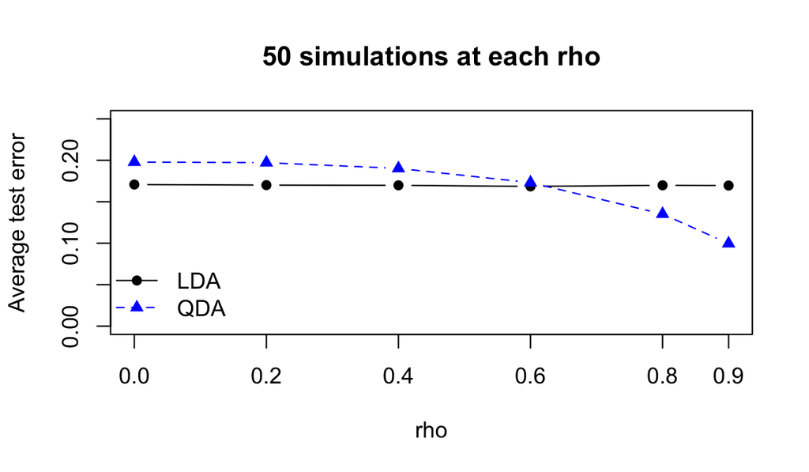

```r
plot(rho_values, average_error[, 1], type = "b", pch = 16,
     ylim = c(0, 0.25), xlab = "rho", ylab = "Average test error",
     main = "50 simulations at each rho", xaxt = "n")
axis(1, at = rho_values)
lines(rho_values, average_error[, 2], type = "b", col = "blue",
      pch = 17, lty = 2)
legend("bottomleft", c("LDA", "QDA"), col = c("black", "blue"),
       pch = c(16, 17), lty = c(1, 2), bty = "n")
```

In the simulations, LDA has a lower average test error at small rho, while QDA has a lower average test error at large rho.

When rho equals zero, both classes have the same true shared covariance matrix. This follows the shared covariance assumption. It gets more stable when LDA needs to estimate fewer parameters. QDA separately estimates two matrices, which may make the estimates less stable.

When rho becomes larger, there is a clear difference between the two covariance structures. In the first class, the first two variables have a positive relationship, while in the second class, they are negatively related. However, LDA uses the same covariance matrix, so it cannot fully explain such a difference. In contrast, QDA uses separate matrices, so it is more suitable for this situation.

The eight noise variables do not have classification information, but the related parameters still need to be estimated. Such noise can increase the uncertainty of estimation and may make the model fit random noise. Since QDA requires estimating more parameters, it may be more influenced.

This is a bias-variance trade-off: LDA can have lower estimation variance, but its shared covariance assumption can cause more bias when rho is large.

### question 4

#### SAheart analysis

Using seed 43209, I split the 462 observations into 323 training and 139 test observations, stratified by `chd`. All nine predictors were used, with `famhist` coded as Absent = 1 and Present = 2. No scaling or PCA was used.

Using cross-validation on the training set, I compared LDA, QDA, and weighted averages of their predicted probabilities. I used the same five stratified folds for all models. Each fitting fold supplied its own class means, covariance estimates, and empirical priors. A blend with weight a uses a times the LDA probability plus (1-a) times the QDA probability. CV error is total out-of-fold mistakes divided by 323.

| Model | CV mistakes | CV error |
| --- | --- | --- |
| LDA | 90 | 0.2786 |
| QDA | 93 | 0.2879 |
| Blend 0.25 | 91 | 0.2817 |
| Blend 0.50 | 89 | 0.2755 |
| Blend 0.75 | 89 | 0.2755 |

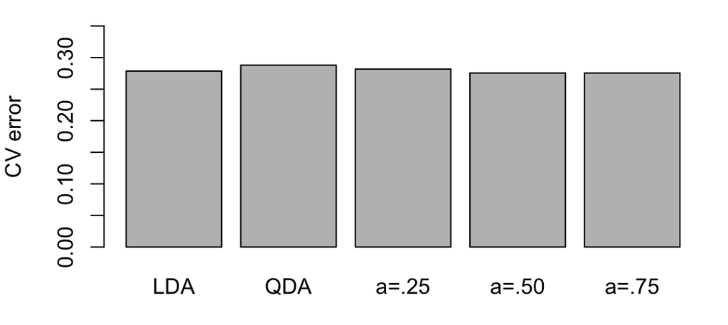

The final selection gives each model a 50 percent weight (Blend 0.50), with CV error 0.2755. The 0.50 and 0.75 blends tied, so the prespecified rule selected the smaller blend weight. The selected combination was refitted using all 323 training observations. Then, I used the test set that did not participate in model selection. There were 36 errors out of 139 observations, and the error rate was 25.9%. The selected model was evaluated only once on this test set.

However, the combined model made only one fewer error than LDA in cross-validation. Therefore, it cannot be concluded that the combined model is generally better. This result depends on one data split and a small set of candidates. The test set was not used to select models or revise the skill.

#### Skill and invocation

The skill is 2929 bytes. It is stored in `homework/week-07/SKILL.md`, outside automatically loaded skill folders. It is supplied only through an explicit request, not installed as an automatic skill.

The invocation requested `compare-lda-qda` using this local file, with the following dataset and settings:

> Use $compare-lda-qda at homework/week-07/SKILL.md to analyze data/saheart.csv, with response chd and all nine other predictors, coding famhist as Absent=1 and Present=2. Use seed 43209, a stratified 70/30 training/test split and shared stratified five-fold CV. Compare ordinary LDA/QDA and blends with LDA weights .25, .5, .75; make no preprocessing changes. First run training/CV selection without evaluating the test set.

After checking the training/CV analysis and locking the selected setting, the selected model was evaluated on the reserved test set. No skill revisions were made after seeing the test result.

[output not shown]